# R Notebook

# Property Price Prediction

```r
library(tidyverse)
library(shiny)
library(leaflet)
```

```r
library(ggplot2)
library(car)
library(corrgram)
library(scatterplot3d)
library(neuralnet)
library(readxl)
Compp07_17 <- read_excel("C:/Users/SStandring/Dropbox/twerk werk/Property Value/07-17.xlsx", col_types = c("text", "text", "text", "date", "numeric", "text", "numeric", "numeric", "numeric", "text", "text", "text", "numeric", "numeric", "numeric", "numeric", "numeric"))
```

# View Data

- Dependent y variable is Sale Price
- Independent x variables are: — Property Address, City, Zip Code, Date, property type, Cap Rate, Building Square footage, Floor Area Ratio, Class, Material, Condition, yeara built, Number of units, Number of tenants, longitude, and latitude.
- Structure of Variables
- Change to appropriate

```r
Compp07_17$PropertyType <- as.factor(Compp07_17$PropertyType)
Compp07_17$`Building Class` <- as.factor(Compp07_17$`Building Class`)
Compp07_17$`Building Condition` <- as.factor(Compp07_17$`Building Condition`)
Compp07_17$BuildingMaterials <- as.factor(Compp07_17$BuildingMaterials)
str(Compp07_17)
```

```
## Classes 'tbl_df', 'tbl' and 'data.frame':    5957 obs. of  17 variables:
##  $ Property Address  : chr  "180 Montgomery St" "700 Lincoln Village Cir" "2020 Kittredge St" "155 Grand Ave" ...
##  $ Property City     : chr  "San Francisco" "Larkspur" "Berkeley" "Oakland" ...
##  $ Property Zip Code : chr  "94104" "94939" "94704" "94612" ...
##  $ Sale Date         : POSIXct, format: "2007-01-18" "2007-07-25" ...
##  $ Sale_Price        : num  1.28e+08 9.45e+07 7.50e+07 7.20e+07 6.65e+07 ...
##  $ PropertyType      : Factor w/ 5 levels "Industrial","Multi-Family",..: 3 2 2 3 3 2 3 3 2 2 ...
##  $ Cap_Rate          : num  3.9 4.28 4.25 5.6 6.61 4 6.5 6 5.5 4.83 ...
##  $ Bldg SF           : num  304162 293198 127830 204336 336000 ...
##  $ Floor Area Ratio  : num  17.473 0.397 1.983 3.114 0.996 ...
##  $ Building Class    : Factor w/ 5 levels "A","B","C","F",..: 1 2 2 1 2 2 2 1 2 1 ...
##  $ Building Condition: Factor w/ 5 levels "Excellent","Good",..: 4 4 4 4 4 4 4 4 2 4 ...
##  $ BuildingMaterials : Factor w/ 6 levels "Masonry","Metal",..: 4 6 5 1 3 6 3 4 5 3 ...
##  $ Year Built        : num  1979 1978 2006 1990 1958 ...
##  $ Number Of Units   : num  NA 342 NA NA NA 250 NA NA 378 153 ...
##  $ Number Of Tenants : num  50 NA NA 11 4 NA 3 5 NA 1 ...
##  $ Longitude         : num  -122 -123 -122 -122 -122 ...
##  $ Latitude          : num  37.8 37.9 37.9 37.8 37.7 ...
```

```r
length(unique(Compp07_17$`Property Address`))
```

```
## [1] 5371
```

# Basic Graphs

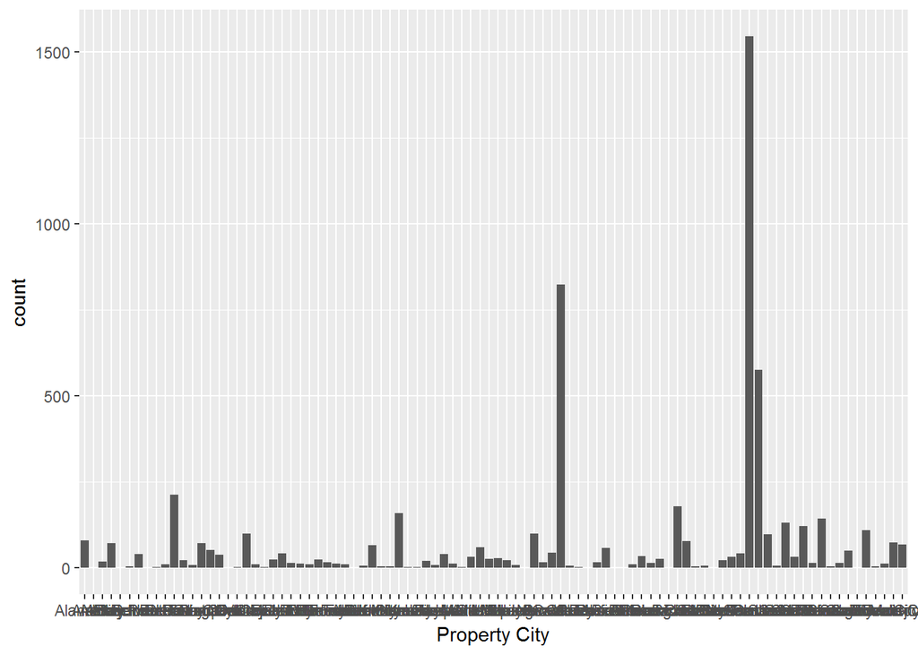

```r
ggplot(Compp07_17, aes(`Property City`)) +
  geom_bar()
```

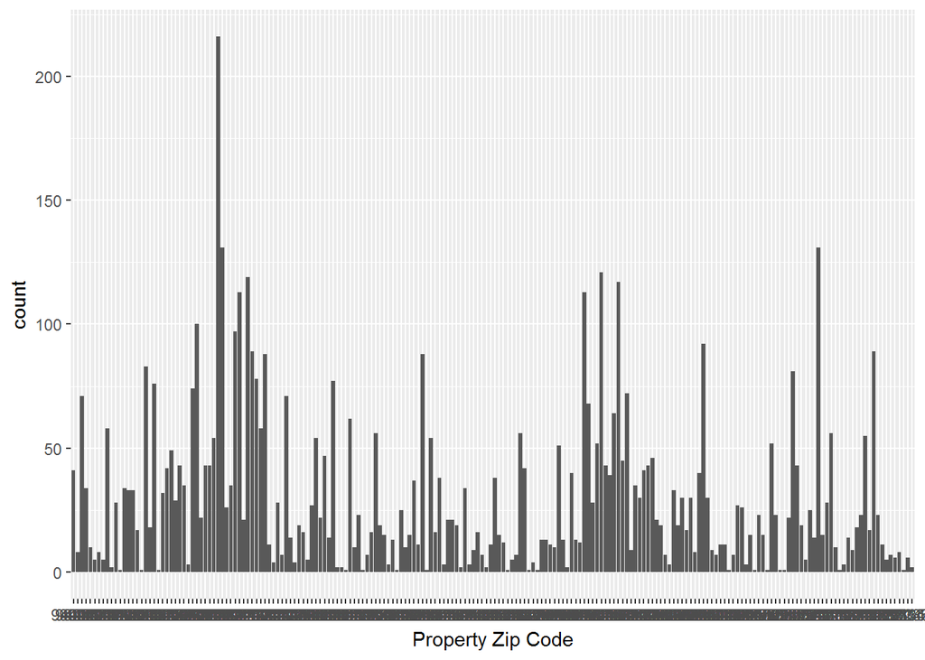

```r
ggplot(Compp07_17,aes(`Property Zip Code`)) +
  geom_bar()
```

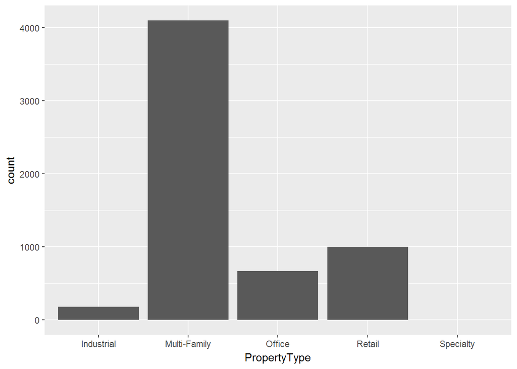

```r
ggplot(Compp07_17,aes(PropertyType)) +
  geom_bar()
```

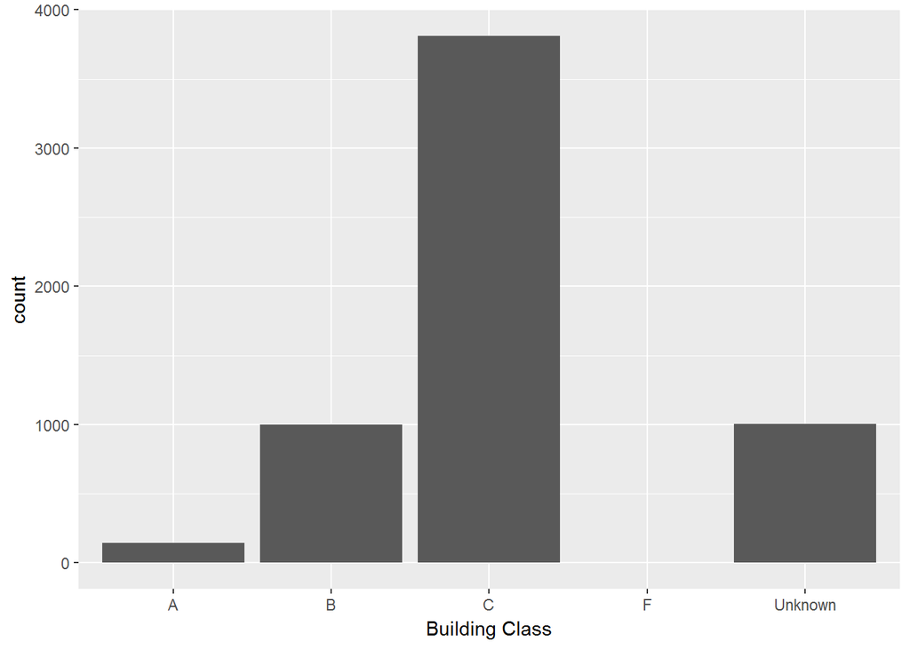

```r
ggplot(Compp07_17,aes(`Building Class`)) +
  geom_bar()
```

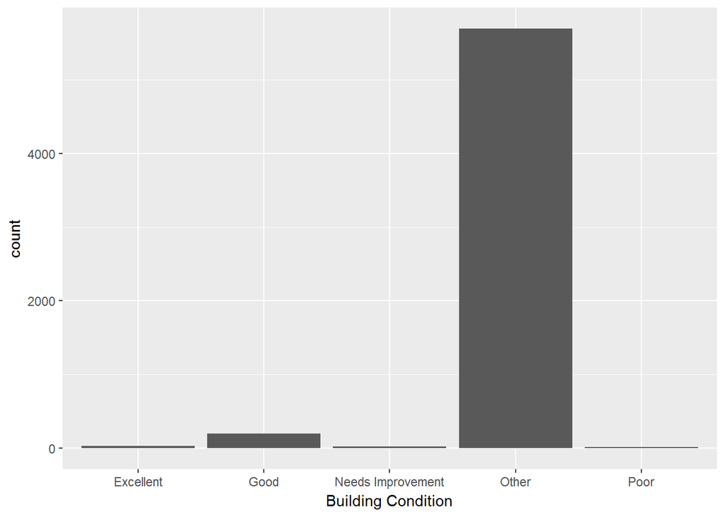

```r
ggplot(Compp07_17,aes(`Building Condition`)) +
  geom_bar()
```

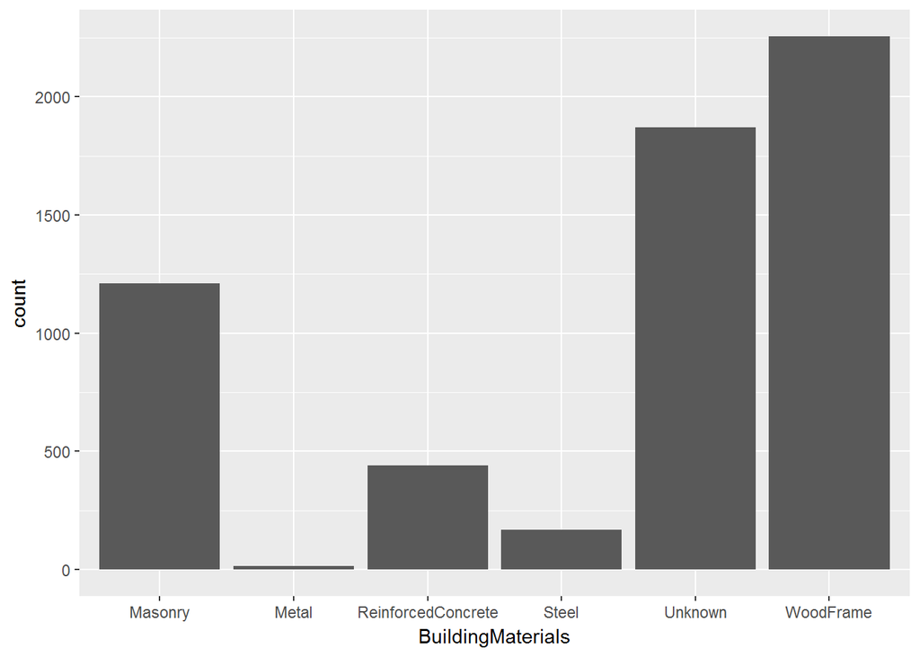

```r
ggplot(Compp07_17,aes(BuildingMaterials)) +
  geom_bar()
```

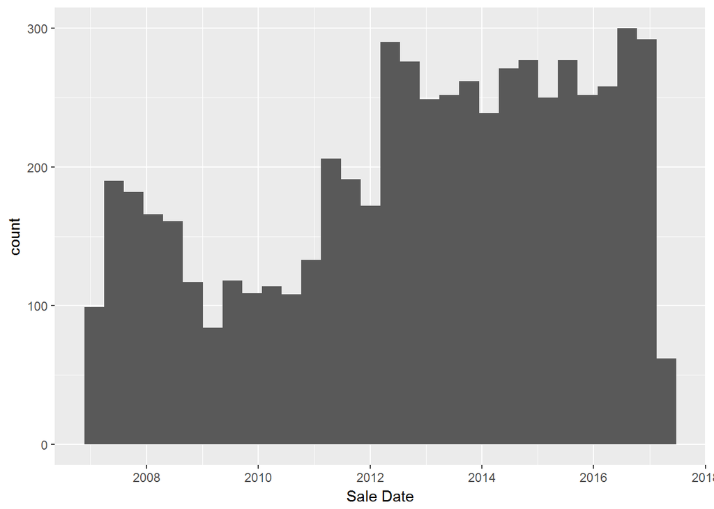

```r
ggplot(Compp07_17,aes(`Sale Date`)) +
  geom_histogram()
```

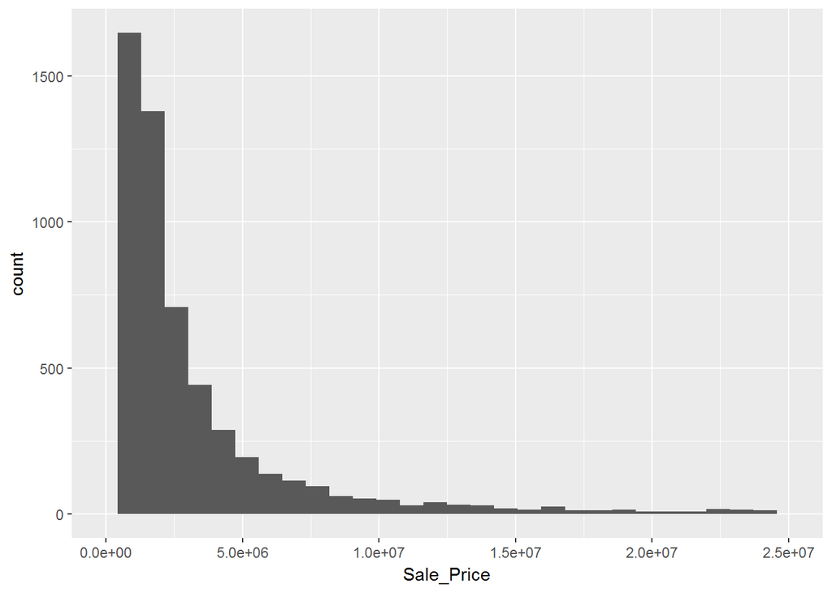

```r
ggplot(Compp07_17,aes(Sale_Price)) +
  geom_histogram() +
  xlim(0,25000000)
```

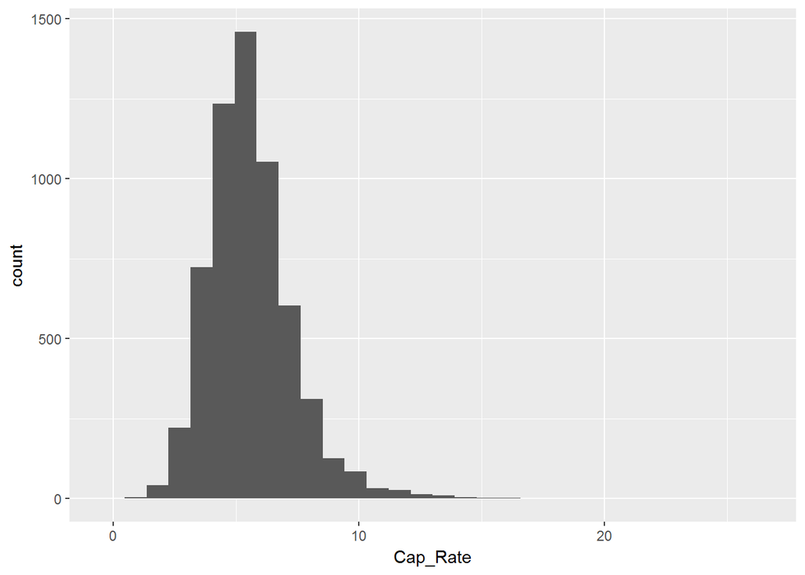

```r
ggplot(Compp07_17,aes(Cap_Rate)) +
  geom_histogram()
```

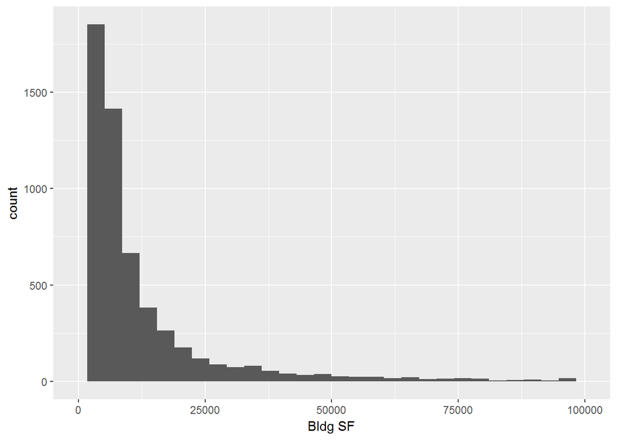

```r
ggplot(Compp07_17,aes(`Bldg SF`)) +
  geom_histogram() +
  xlim(0,100000)
```

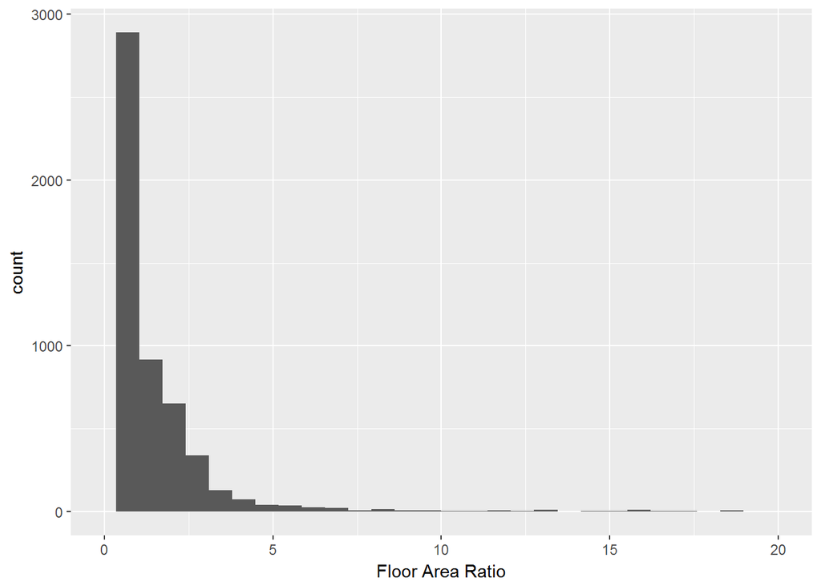

```r
ggplot(Compp07_17,aes(`Floor Area Ratio`)) +
  geom_histogram() +
  xlim(0,20)
```

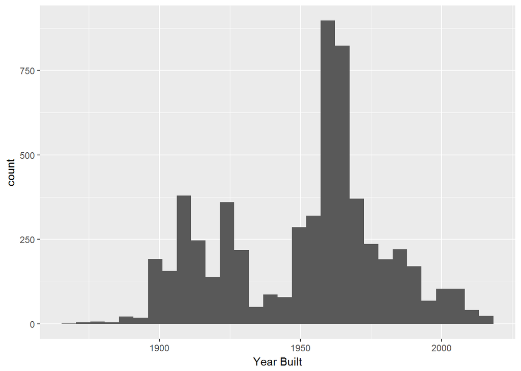

```r
ggplot(Compp07_17,aes(`Year Built`)) +
  geom_histogram()
```

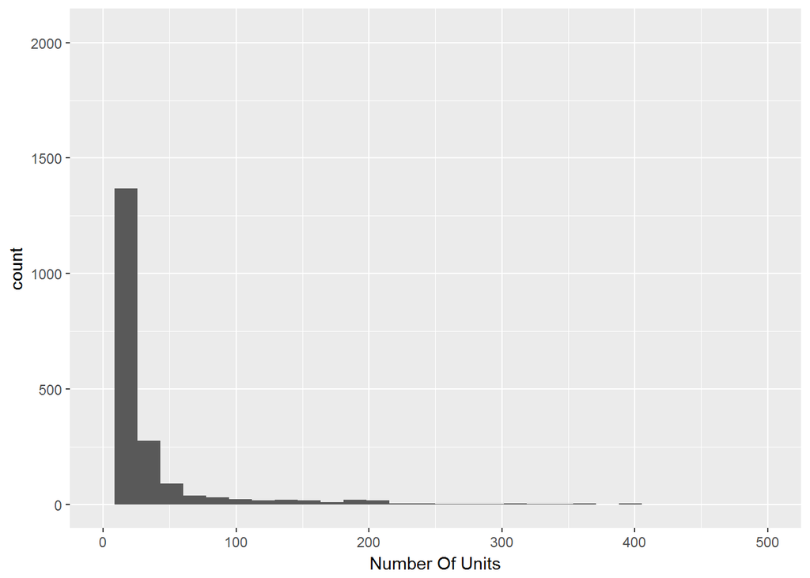

```r
ggplot(Compp07_17,aes(`Number Of Units`)) +
  geom_histogram() +
  xlim(0,500)
```

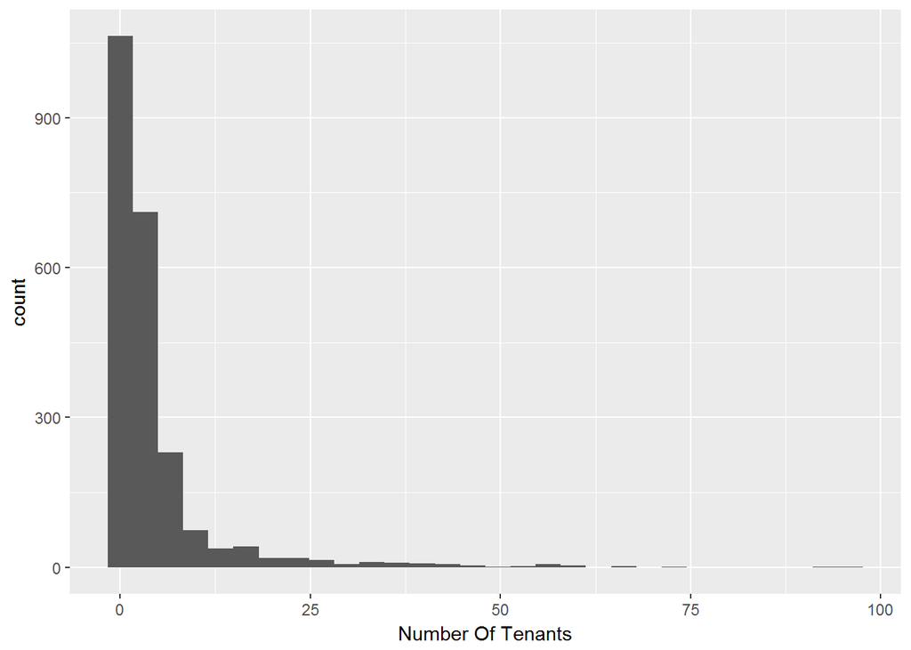

```r
ggplot(Compp07_17,aes(`Number Of Tenants`)) +
  geom_histogram()
```

## Transform skewed data

-Price, Building Square foot, & Floor Area Ratio

-View new transformed price by categorical variables —We see there is variance in ranges when looking at the cat. variables and price which may mean they have an impact.

-View transformed price by numerics also —We see there is hopeful correlation between building square footage/Floor Area Ratio and price (but they may need to be looked at in the transformed form)

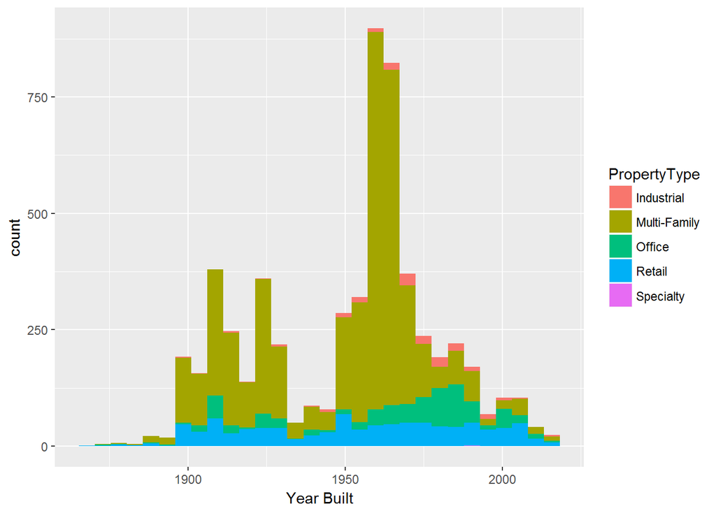

```r
Compp07_17$Trans_Price <- log(Compp07_17$Sale_Price)
Compp07_17$Trans_BldgSF <- log(Compp07_17$`Bldg SF`)
Compp07_17$Trans_FAR <- log(Compp07_17$`Floor Area Ratio`)

Complete_07_17 <- Compp07_17 %>%
  filter(!is.na(`Number Of Units` & !is.na(`Number Of Tenants`)))

ggplot(Compp07_17,aes(`Year Built`, group = PropertyType, fill = PropertyType)) +
  geom_histogram()
```

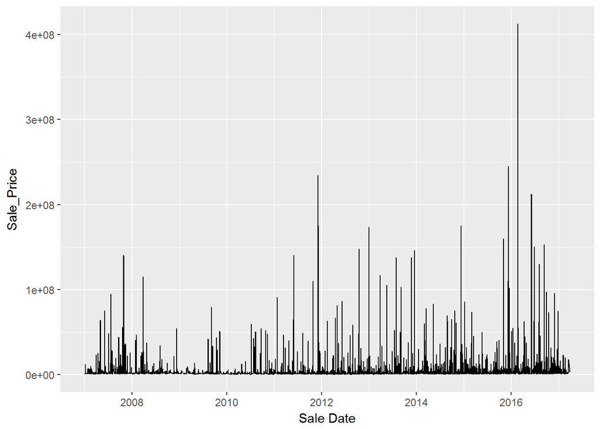

```r
Compp07_17 %>%
  filter(PropertyType ==  'Multi-Family') %>%
  ggplot(aes(`Sale Date`, Sale_Price)) +
  geom_line()
```

```r
  ylim(0,25000000)
```

```
## <ScaleContinuousPosition>
##  Range:
##  Limits:    0 -- 2.5e+07
```

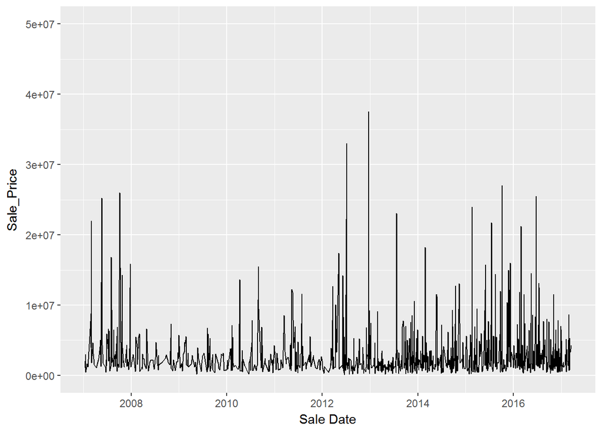

```r
Compp07_17 %>%
  filter(PropertyType == "Retail") %>%
  ggplot(aes(`Sale Date`, Sale_Price)) +
  geom_line() +
  ylim(0,50000000)
```

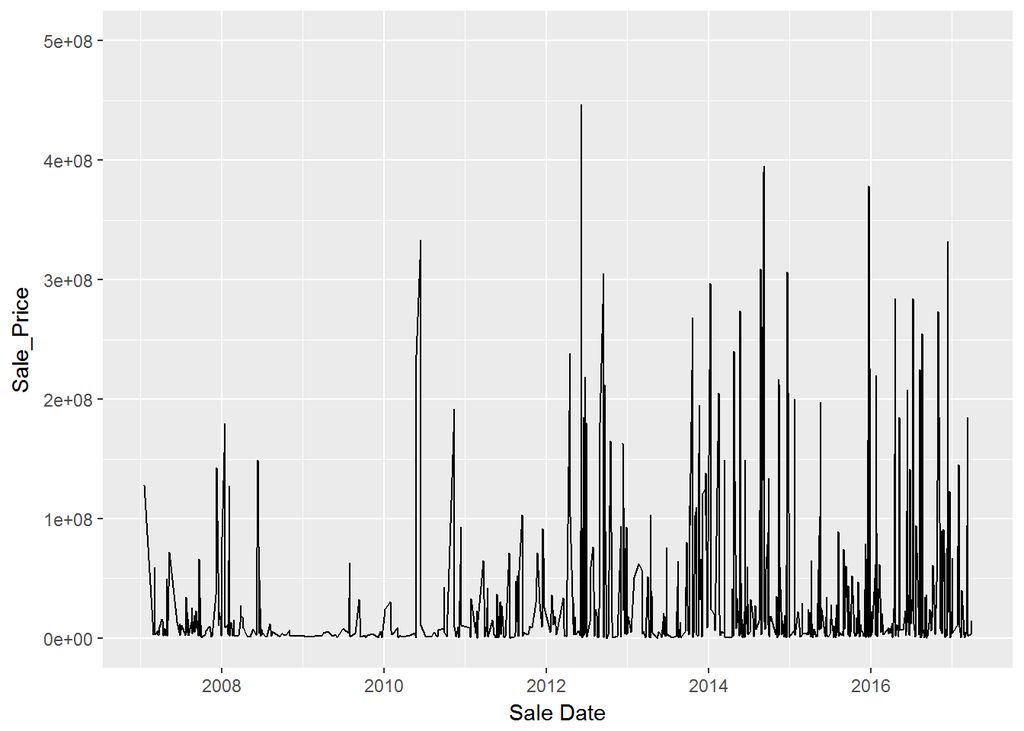

```r
Compp07_17 %>%
  filter(PropertyType == "Office") %>%
  ggplot(aes(`Sale Date`, Sale_Price)) +
  geom_line() +
  ylim(0,500000000)
```

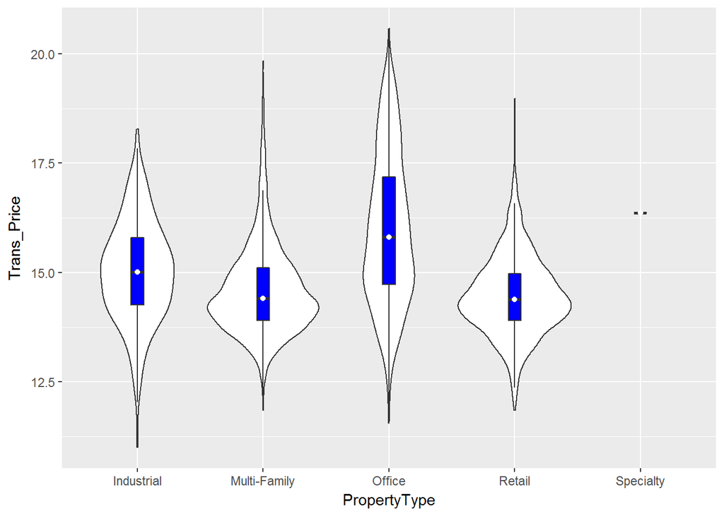

```r
ggplot(Compp07_17,aes(PropertyType,Trans_Price)) +
  geom_violin() +
  geom_boxplot(width = .1, fill = "blue", outlier.shape = NA) +
  stat_summary(fun.y = "median", geom = "point", col = "white")
```

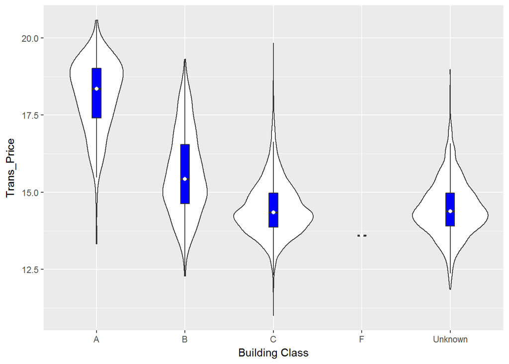

```r
ggplot(Compp07_17,aes(`Building Class`,Trans_Price)) +
  geom_violin() +
  geom_boxplot(width = .1, fill = "blue", outlier.shape = NA) +
  stat_summary(fun.y = "median", geom = "point", col = "white")
```

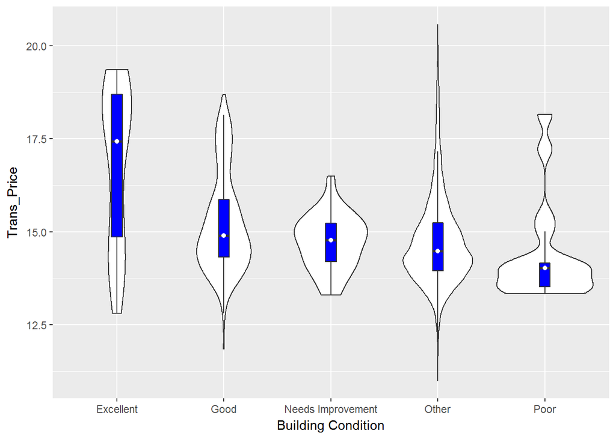

```r
ggplot(Compp07_17,aes(`Building Condition`,Trans_Price)) +
  geom_violin() +
  geom_boxplot(width = .1, fill = "blue", outlier.shape = NA) +
  stat_summary(fun.y = "median", geom = "point", col = "white")
```

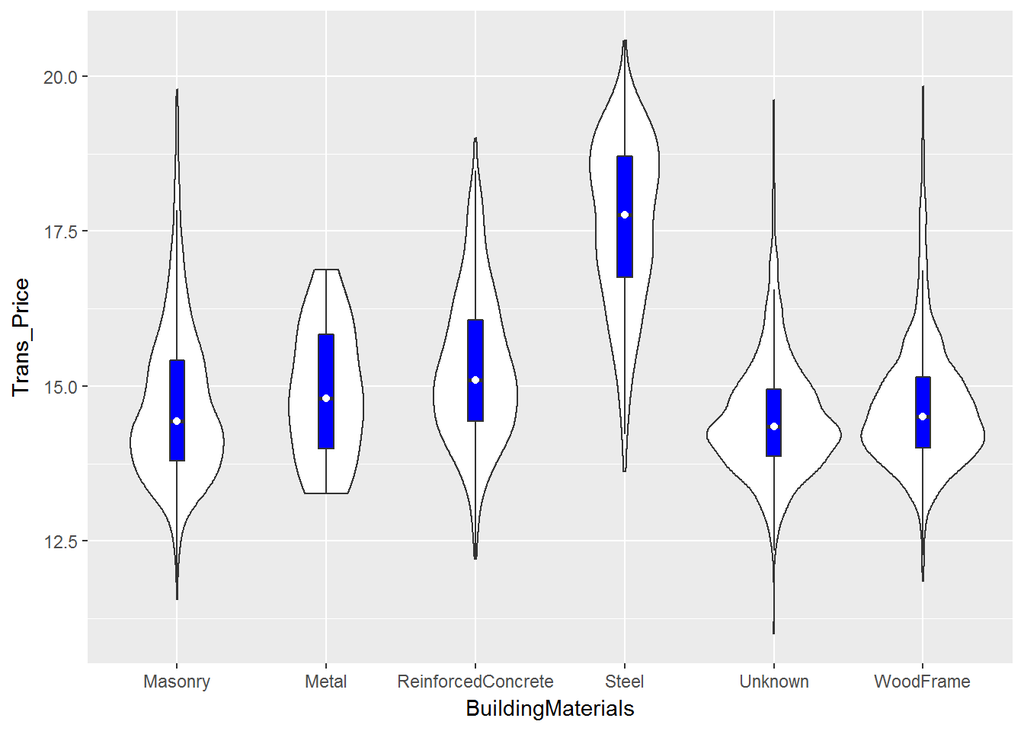

```r
ggplot(Compp07_17,aes(BuildingMaterials,Trans_Price)) +
  geom_violin() +
  geom_boxplot(width = .1, fill = "blue", outlier.shape = NA) +
  stat_summary(fun.y = "median", geom = "point", col = "white")
```

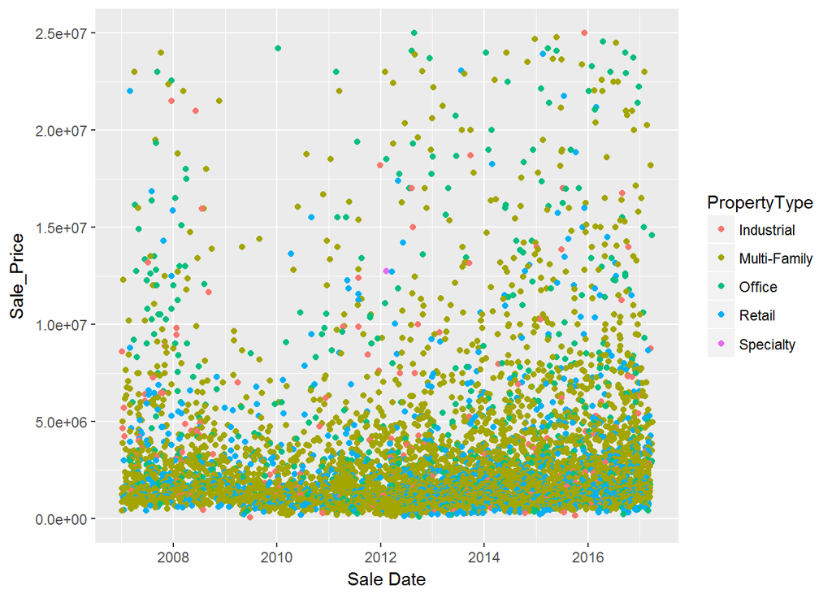

```r
ggplot(Compp07_17,aes(`Sale Date`,Sale_Price,colour = PropertyType)) +
  geom_point() +
  ylim(0,25000000)
```

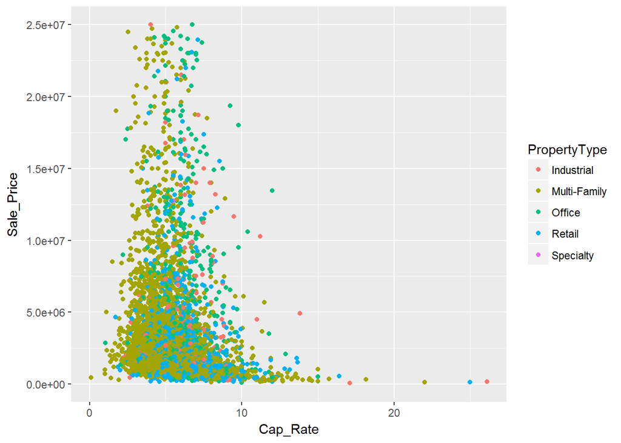

```r
ggplot(Compp07_17,aes(Cap_Rate,Sale_Price,colour = PropertyType)) +
  geom_point() +
  ylim(0,25000000)
```

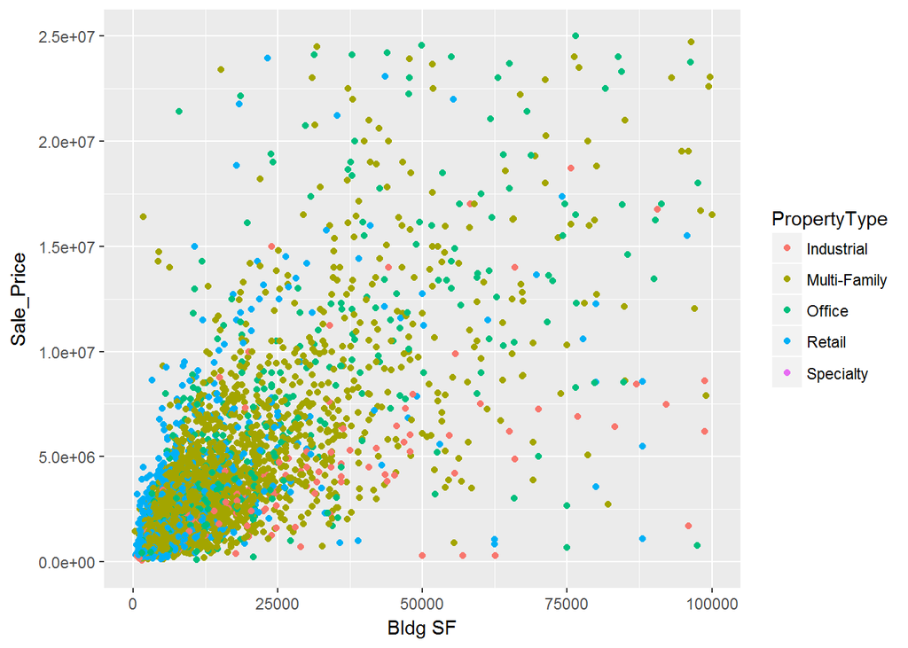

```r
ggplot(Compp07_17,aes(`Bldg SF`,Sale_Price,colour = PropertyType)) +
  geom_point() +
  xlim(0,100000) +
  ylim(0,25000000)
```

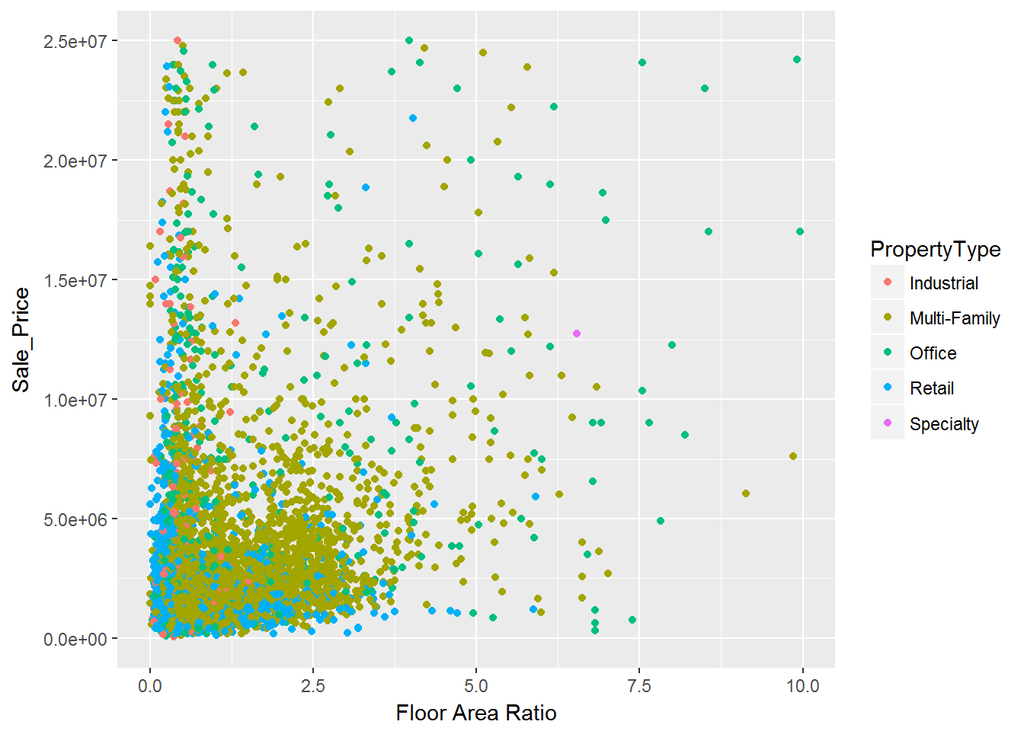

```r
ggplot(Compp07_17,aes(`Floor Area Ratio`,Sale_Price,colour = PropertyType)) +
  geom_point() +
  xlim(0,10) +
  ylim(0,25000000)
```

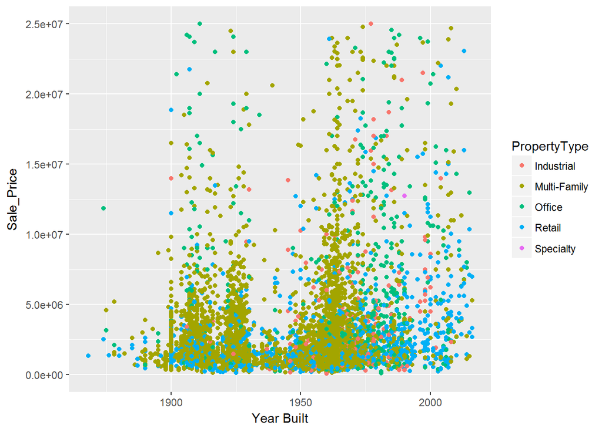

```r
ggplot(Compp07_17,aes(`Year Built`,Sale_Price,colour = PropertyType)) +
  geom_point() +
  ylim(0,25000000)
```

In the transformed graphs there is definitely some better correlation between the independent variables and transformed price. There will definitely need to be included in our model

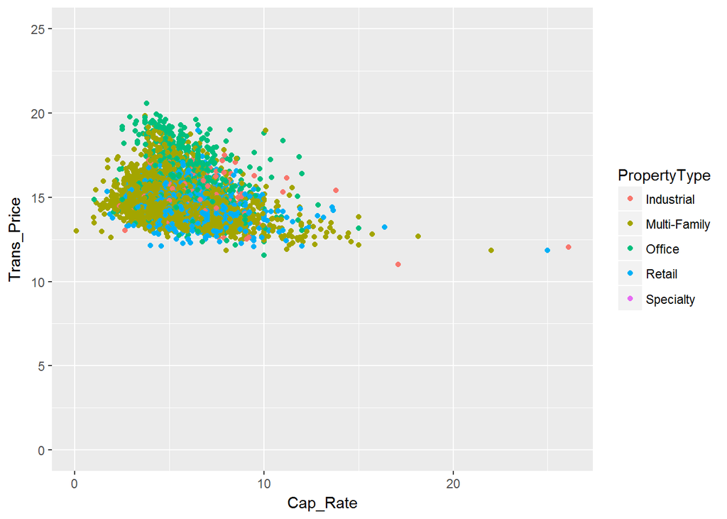

```r
ggplot(Compp07_17,aes(Cap_Rate,Trans_Price,colour = PropertyType)) +
  geom_point() +
  ylim(0,25)
```

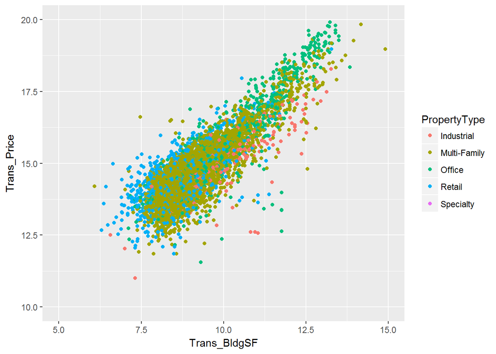

```r
ggplot(Compp07_17,aes(Trans_BldgSF,Trans_Price,colour = PropertyType)) +
  geom_point() +
  xlim(5,15) +
  ylim(10,20)
```

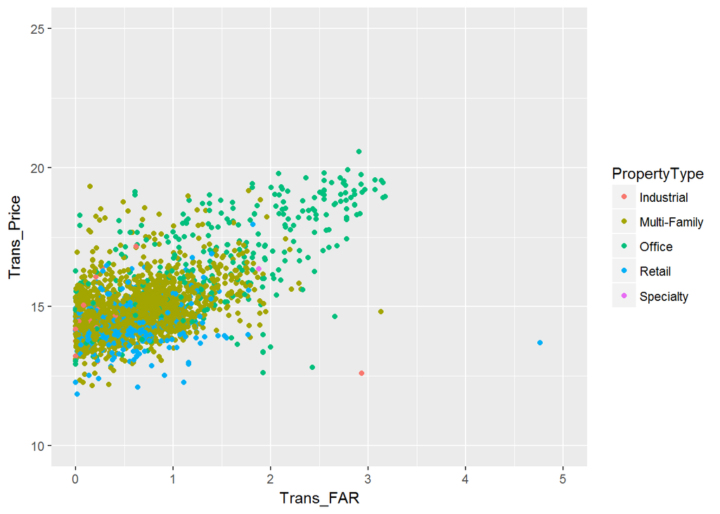

```r
ggplot(Compp07_17,aes(Trans_FAR,Trans_Price,colour = PropertyType)) +
  geom_point() +
  xlim(0,5) +
  ylim(10,25)
```

This is just some more info on the spread on the data, obviously multi-family is the large portion of our sample. And the uneven spread of the other categorical variables to property type may mean Building Class, Material, and Condition cannot be used in our analysis model.

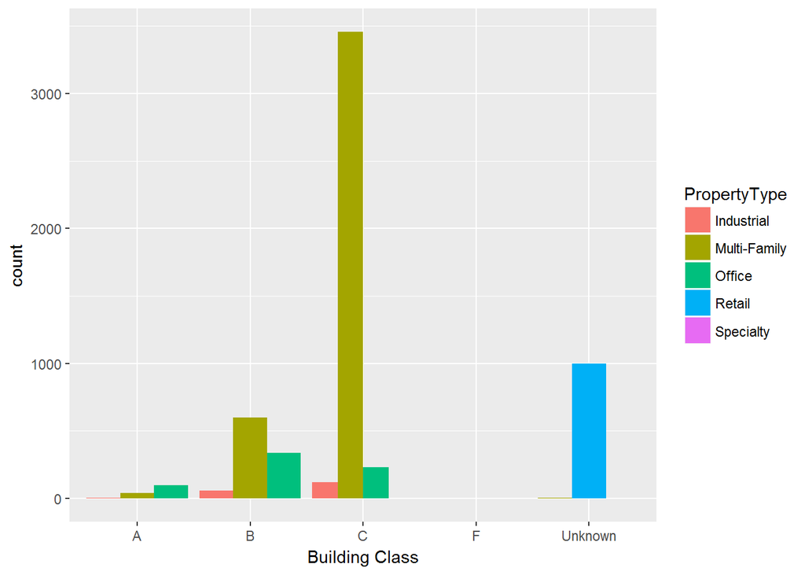

```r
ggplot(Compp07_17,aes(`Building Class`, fill = PropertyType)) +
  geom_bar(stat = 'count', position = "dodge")
```

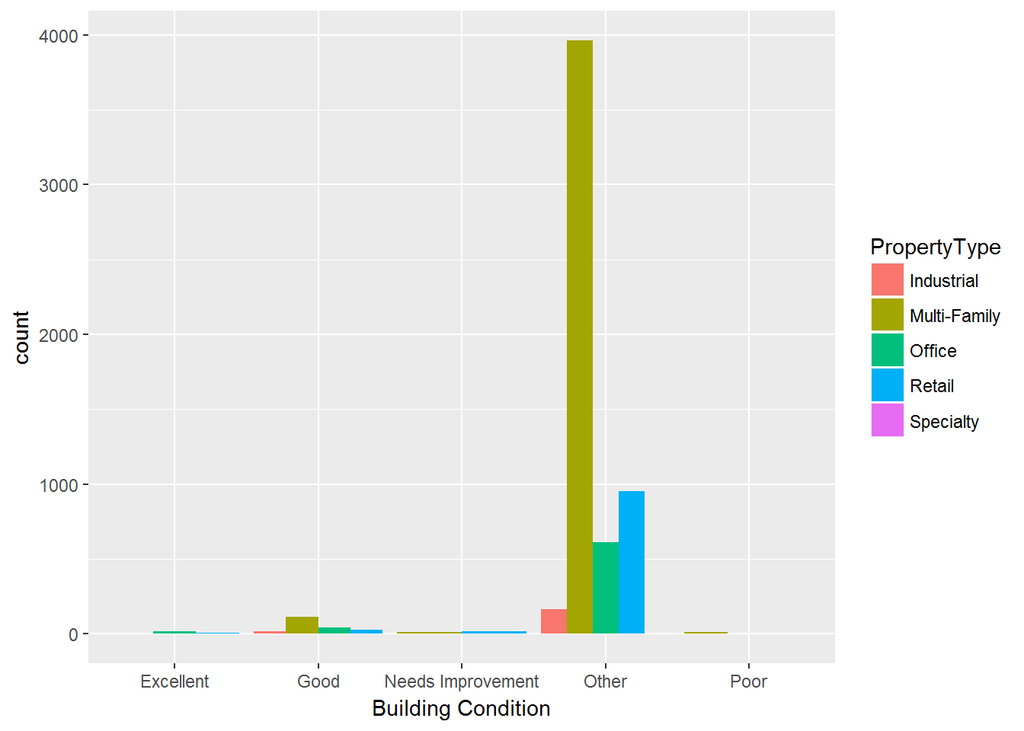

```r
ggplot(Compp07_17,aes(`Building Condition`, fill = PropertyType)) +
  geom_bar(stat = 'count', position = 'dodge')
```